# Data exploration strategies using R

#### Data exploration

We will start by considering how we can visualise **distributions** in data. How we do this depends on the type of variable, categorical or numerical:

- A variable is categorical if it can only take one of a small set of values. To examine the distribution of a categorical variable, you can use a bar chart. The height of the bars displays how many observations occurred with each x value.
- A variable is numerical (or quantitative) if it can take on a wide range of numerical values, and it is sensible to add, subtract, or take averages with those values. Numerical variables can be continuous or discrete.

We know from looking at the structure of our data that it is numerical; remember categorization when we used **glimpse** to look at the data? To examine the distribution of these types of data we use **geom_histogram**. Notice here that we are shortening the ggplot code by adding the aesthetics to the ggplot() call and dropping out some of the other commands (e.g. mapping etc).

```r
ggplot(BhamData, aes(x = Qualification)) +
  geom_histogram(binwidth = 10)
```

Urgh this looks ugly. This is because we have percentage data so to see the full range we need to increase the number of bins to say 1 (gives us a maximum of 100 as they are percentages).

```r
ggplot(BhamData, aes(x = Qualification)) +
  geom_histogram(binwidth = 1)
```

Maybe a little too many but it does indicate there might be a few extreme points in our data at the top end of LSOAs for educational outcomes. Perhaps 5 would close off the gaps.

```r
ggplot(BhamData, aes(x = Qualification)) +
  geom_histogram(binwidth = 5)
```

We can also use a density plot is a smoothed-out version of a histogram and a practical alternative, particularly for continuous data that comes from an underlying smooth distribution using **geom_density()**. Although they show fewer details than a histogram they are useful for understanding the shape of a distribution and make it easier to ‘see’ the shape of the distribution, particularly with respect to modes and skewness.

```r
ggplot(BhamData, aes(x = Qualification)) +
  geom_density()
```

We can see these data are very skewed to the right (or positively skewed) (Figure 5). Yes I know the lump is on the left but this is about the long tail on the distribution which does sit to the right!

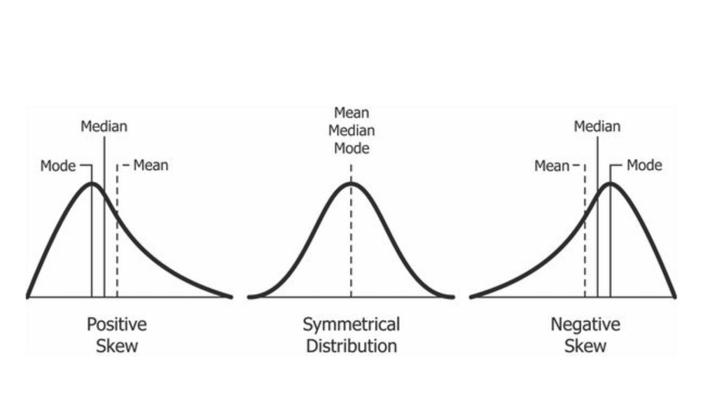

**Figure 5**: Skewness in relation to the mean and median.

And read this: https://en.wikipedia.org/wiki/Skewness

Like all geoms you can add different aesthetics to change line colour, line widths and so on and also add labels etc. They are described here in detail: https://ggplot2.tidyverse.org/reference/geom_density.html

#### TASK 3: Try creating some new code that adds labels the X variable axis not the Y and a title [~ 5 min].

Another way to visual distributions in to use a **q-qplot**. A Q-Q plot, short for “quantile-quantile” plot, is used to assess whether or not a set of data potentially came from some theoretical distribution. In most cases, this type of plot is used to determine whether or not a set of data follows a normal distribution.

If the data are normally distributed, the points in a Q-Q plot will lie on a straight diagonal line. Conversely, if the points deviate significantly from the straight diagonal line, then it’s less likely that the data is normally distributed. We know from out histogram that our qualification data are skewed so it is unlikely to be normally distributed. We address why this might be important in later classes so don’t worry about it now.

In ggplot the we use you can use the **stat_qq()** and **stat_qq_line()** functions as follows:

```r
ggplot(BhamData, aes(sample=Qualification)) +
  stat_qq() +
  stat_qq_line()
```

```r
#make this example reproducible
set.seed(1)

#create some fake data that follows a normal distribution for 200 datapoints
df <- data.frame(col=rnorm(200))

#create Q-Q plot
ggplot(df, aes(sample=col)) +
  stat_qq() +
  stat_qq_line()
```

#### TASK 4: Try to create a histogram and density plot of the new data we’ve just created.[~ 5 min]

**HINT:** Check the dataframe using the **str** or **glimpse** functions. Here is a schematic of the code you need. Remember it is called **df**.

Histogram:

The code will look like this [Check the syntax you do not need the quote marks]:

ggplot(data=**‘add in the dataframe name’**, aes(x=**‘add in the column name’**)) + geom_histogram(binwidth = .25)

Density plot:

ggplot(data=**‘add in the dataframe name’**, aes(x=**‘add in the column name’**)) + geom_density()

We have gone about as far we can looking at the variation and distribution of our numerical data columns but there is on thing left to do. That is consider whether we have any **outliers** or points that sit out the expected distributions. **Boxplots** are excellent for this but we cannot easily use them for continuous numerical data; they work better for categorical data but we can use them for continuous data.

```r
ggplot(BhamData, aes(x = 1, y = Qualification)) +
  geom_boxplot() +
  scale_x_continuous(breaks = NULL) # we need this new code otherwise R will add a 'fake' x axis!
```

Boxplots (Figure 6) are very useful for visualising the distribution of data. The black in the middle is the median (not the mean), the box around it shows the upper (3rd) quartile (75%) and the lower (1st) quartile (25%) and the whiskers or lines are the maxima and minima. The dots are potential outliers. They may not be true outliers in the statistical sense. We’ll discover how to be sure of this in later workshops.

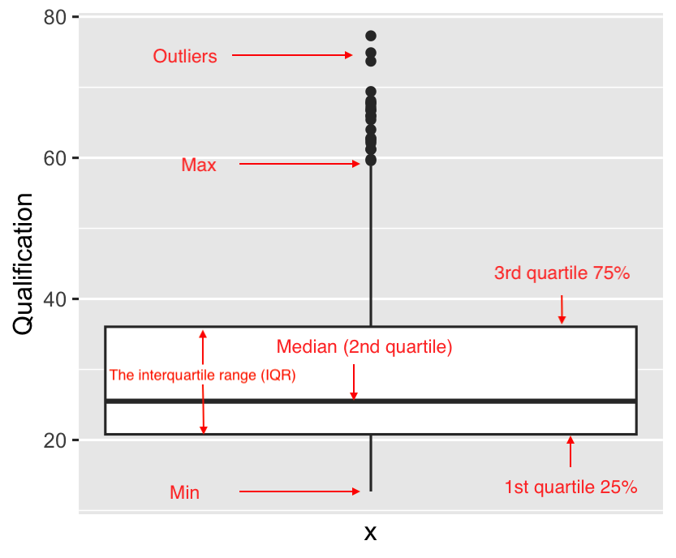

**Figure 6**: Explanation of the elements of a boxplot.

A boxplot relates to the density plot and a histogram nicely (Figure 7).

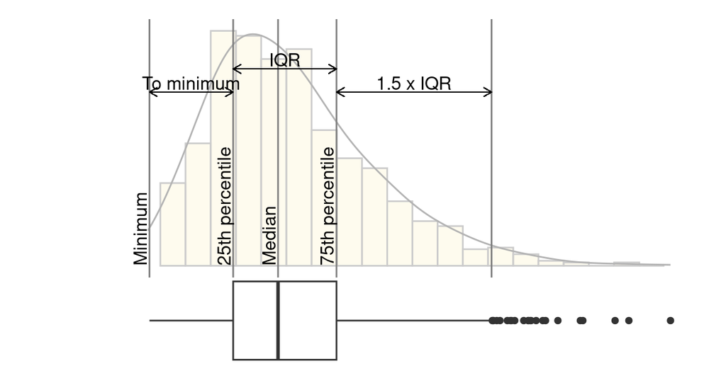

**Figure 7**: A comparison of a boxplot, density plot and histogram.

### Follow on work

Read chapter 1 of https://r4ds.hadley.nz/data-visualize which we replicated with our plotting exercise today. Try completing Exercises 1-5 or more if you are coping well with the work!

Jon Sadler Oct 2024